# 02_Centrality_Analysis

Edoardo Diana

2025-11-15

## Indice

1 : Caricare le librerie e dati da usare 2 : Calcolo di tutte le metriche di centralità

```
  * 2.1 : Degree centrality
      - In-degree
      - Out-degree
  * 2.2 : Closness Centrality (inutile)
  * 2.3 : Betweenness Centrality
  * 2.4 : Eigenvector Centrality (inutile)
  * 2.5 : Page Rank Centrality
  * 2.6 : HITS
  * 2.7 : Katz Centrality
```

3 : Paragoni tra le centralità 4 : Power 5 : Compare Power and Katz Centrality 6 : Uso delle 2 matrici proiezioni A %*% t(A) e t(A) %*% A (prodotto matriciale)

```
    - Trova le 30 coppie (i, j) con più paper citati in comune (common successors)

    - Trova le 30 coppie con più paper citanti in comune (common predecessors)
```

7 : Salvataggio Metriche computate

## 1 : Caricare le librerie e dati da usare

```r
library(igraph)
library(dplyr)
library(tidygraph)
library(ggrepel)
library(ggplot2)
library(ggraph)
library(Matrix)
library(corrplot)
library(tidyr)
```

Caricamento dati dal notebook precedente

```r
dir_processed <- "../data/processed"

graph <- readRDS(file.path(dir_processed, "graph.rds"))
content_nodes <- readRDS(file.path(dir_processed, "content_nodes.rds"))
edge_table_named <- readRDS(file.path(dir_processed, "edges.rds"))

cat("Oggetti caricati correttamente\n")
```

```
## Oggetti caricati correttamente
```

## 2 : Calcolo di tutte le metriche di centralità

- Degre Centrality :
  - In-degree Centrality
  - Out-degree Centrality
- Closness Centrality
- Betweenness Centrality
- Eigenvector Centrality
- Page Rank Centrality
- HITS
- Katz Centrality

```r
graph <- graph %>%
  activate(nodes) %>%
  mutate(
    indegree = centrality_degree(mode = "in"),
    outdegree = centrality_degree(mode = "out"),
    pagerank = centrality_pagerank(),
    closeness = centrality_closeness(),
    betweenness = centrality_betweenness()
  )
```

## 2.1 Degree centrality

Il degree (grado) è il numero di archi incidenti ad un nodo.

Un nodo è importante se è linkato da tanti altri nodi.

Qui lavoriamo con un grafo diretto, dunque ne avrò 2 tipi di degree :

- In-degree: numero di archi entranti (citazioni ricevute da un paper)
- Out-degree: numero di archi uscenti (citazioni fatte da un paper)

Prendo i top 500 nodi più centrali considerando solo in-degree

```r
top_ids <- graph %>%
  as_tibble() %>%
  top_n(500, indegree) %>%
  pull(name)

subgraph_top <- graph %>%
  activate(nodes) %>%
  filter(name %in% top_ids)
```

Visualizzazione della rete considerando In-degree

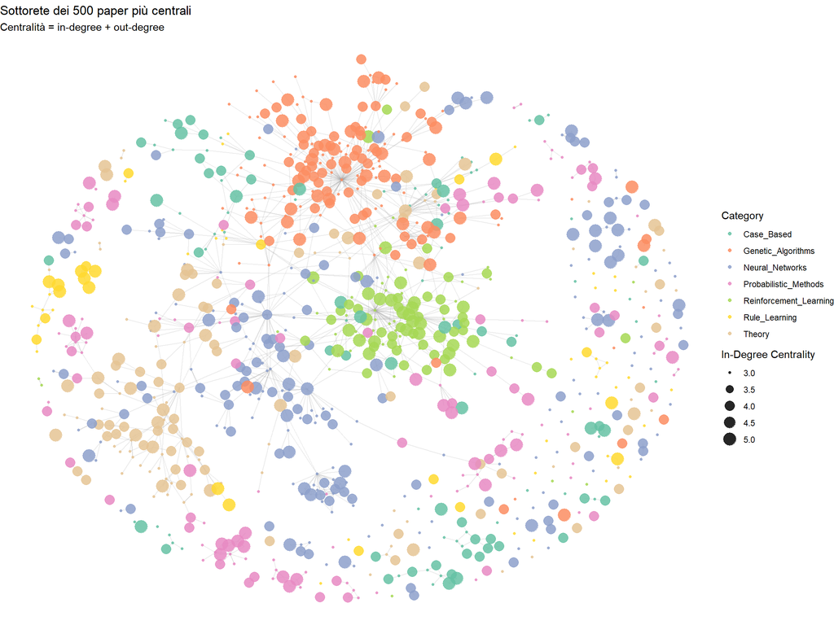

```r
set.seed(42)

ggraph(subgraph_top, layout = "fr") +
  geom_edge_link(alpha = 0.2, edge_colour = "gray60") +
  geom_node_point(aes(color = category, size = indegree), alpha = 0.85) +
  scale_color_brewer(palette = "Set2") +
  labs(
    title = "Sottorete dei 500 paper più centrali",
    subtitle = "Centralità = in-degree + out-degree",
    size = "In-Degree Centrality",
    color = "Category"
  ) +
  theme_void() +
  theme(legend.position = "right")
```

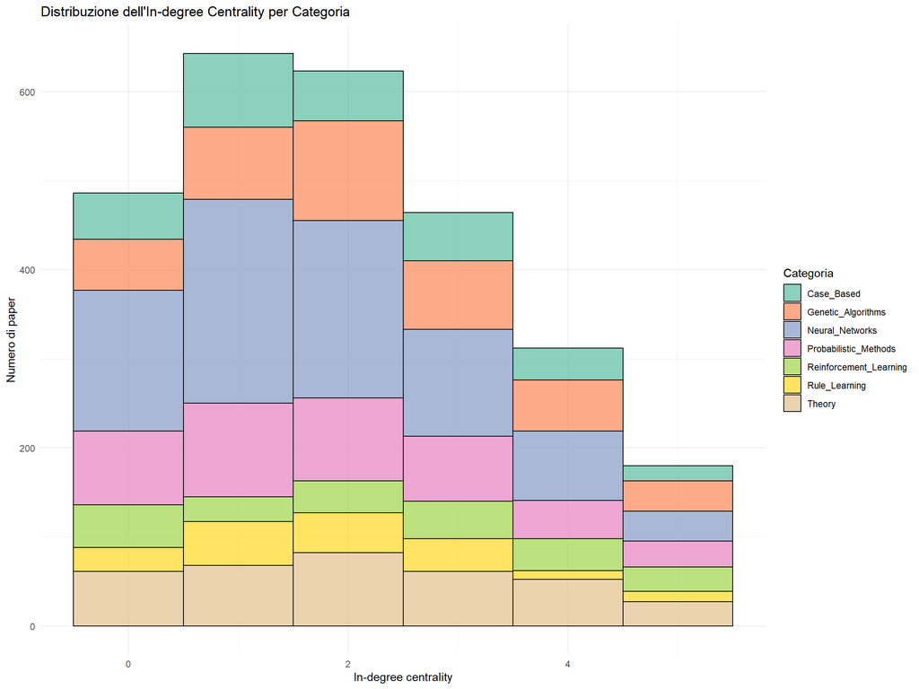

```r
graph %>%
  activate(nodes) %>%
  as_tibble() %>%
  ggplot(aes(x = indegree, fill = category)) +
  geom_histogram(binwidth = 1, position = "stack", color = "black", alpha = 0.75) +
  scale_fill_brewer(palette = "Set2") +
  labs(
    title = "Distribuzione dell'In-degree Centrality per Categoria",
    x = "In-degree centrality",
    y = "Numero di paper",
    fill = "Categoria"
  ) +
  theme_minimal()
```

## 2.2 : Closeness centrality

La closeness indica quanto un nodo si trova “vicino” a tutti gli altri, cioè l’inverso della distanza media (numero di passi minimi) dagli altri nodi raggiungibili.

Un paper con closeness alta è raggiungibile facilmente dagli altri e potenzialmente è un “crocevia” di informazioni

Ho però che la mia rete è “non fortemente connessa”, infatti la struttura delle citazioni è molto asimmetrica e “sparsa”.

In questi casi la closeness perde di informatività.

Infatti è molto informativa solo per reti fortemente connesse, mentre in reti grandi e dirette ho che molte distanze sono infinite.

La presenza di numerosi nodi isolati e la frammentazione della rete rendono la closeness centrality poco informativa, poiché questa metrica assume che tutti i nodi possano raggiungere tutti gli altri nodi, condizione non verificata in questa rete.

Elenco i top 500 paper per Closeness

```r
top_closeness <- graph %>%
  as_tibble() %>%
  arrange(desc(closeness)) %>%
  select(name, closeness, category) %>%
  head(500)

print(top_closeness)
```

```
## # A tibble: 500 × 3
##    name   closeness category
##    <chr>      <dbl> <chr>
##  1 37879          1 Probabilistic_Methods
##  2 31349          1 Neural_Networks
##  3 217139         1 Case_Based
##  4 249858         1 Theory
##  5 354004         1 Probabilistic_Methods
##  6 242637         1 Neural_Networks
##  7 100701         1 Case_Based
##  8 13966          1 Reinforcement_Learning
##  9 32872          1 Reinforcement_Learning
## 10 310530         1 Case_Based
## # ℹ 490 more rows
```

```r
# Estraggo solo i nomi dei nodi con closeness più alta
top_ids_closeness <- graph %>%
  as_tibble() %>%
  top_n(500, closeness) %>%
  pull(name)

# Creo la sottorete sui nodi con closeness più alta
subgraph_closeness <- graph %>%
  activate(nodes) %>%
  filter(name %in% top_ids_closeness)
```

## 2.3 : Betweenness centrality

La betweenness misura quante volte un nodo appare nei cammini minimi tra altri nodi. Rileva i “ponti” critici della rete.

Elenco i top 10 paper per Betweenness

High betweenness = ruolo di ponte/intermediazione.

Rimuovere nodi con alta betweenness casua la più grande distruzione delle comunicazioni tra gli altri vertici.

Prendo i Top 10 paper per Betweenness, mostro la tabella ed il grafo a barre.

Infine la distribuzione dei paper in merito alla Betweenness.

```r
top_betw <- graph %>%
  as_tibble() %>%
  arrange(desc(betweenness)) %>%
  select(name, betweenness, category) %>%
  head(10)

print(top_betw)
```

```
## # A tibble: 10 × 3
##    name   betweenness category
##    <chr>        <dbl> <chr>
##  1 1272         9524. Theory
##  2 13686        8970. Neural_Networks
##  3 6184         8544. Reinforcement_Learning
##  4 85688        7271  Rule_Learning
##  5 887          7210. Genetic_Algorithms
##  6 8224         6908. Theory
##  7 6213         6223. Reinforcement_Learning
##  8 3229         6014. Neural_Networks
##  9 210871       5712. Genetic_Algorithms
## 10 22563        3969. Neural_Networks
```

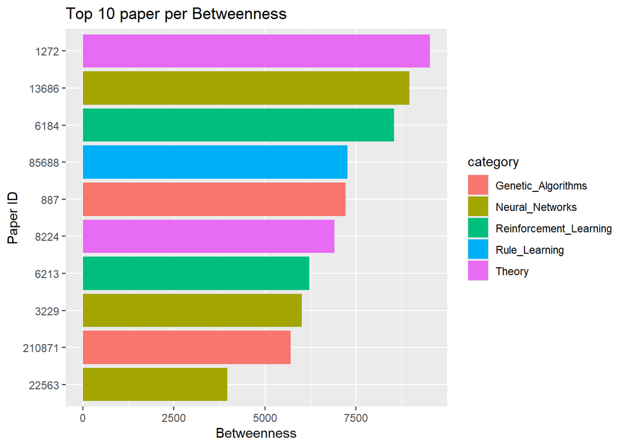

```r
ggplot(top_betw, aes(x = reorder(name, betweenness), y = betweenness, fill = category)) +
  geom_col() +
  coord_flip() +
  labs(
    title = "Top 10 paper per Betweenness",
    x = "Paper ID",
    y = "Betweenness"
  )
```

Distribuzione della Betweenness centrality e Distribuzione della Betweenness centrality per categoria

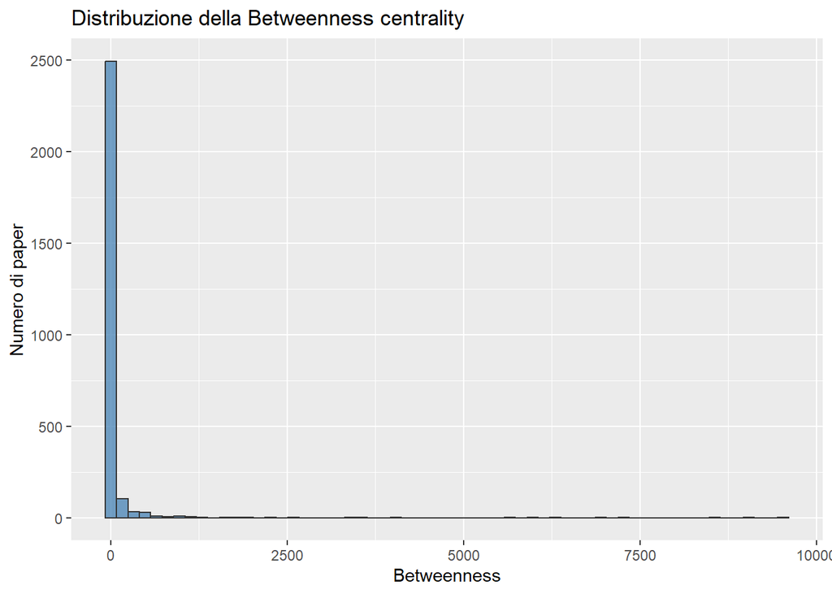

```r
# Distribuzione della Betweenness centrality

graph %>%
  as_tibble() %>%
  ggplot(aes(betweenness)) +
  geom_histogram(bins = 60, fill = "steelblue", color = "gray20", alpha = 0.75) +
  labs(
    title = "Distribuzione della Betweenness centrality",
    x = "Betweenness",
    y = "Numero di paper"
  )
```

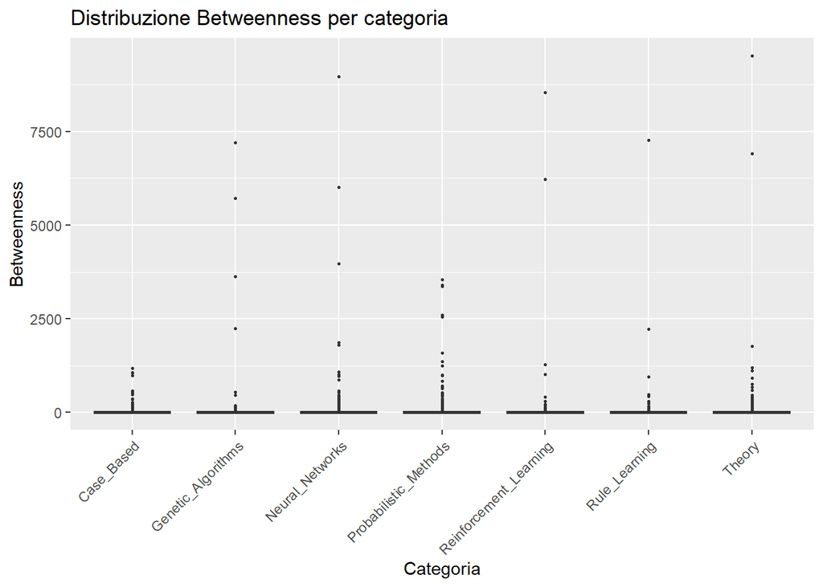

```r
# Distribuzione Betweenness per categoria

graph %>%
  as_tibble() %>%
  ggplot(aes(x = category, y = betweenness, fill = category)) +
  geom_boxplot(show.legend = FALSE, outlier.size=0.5) +
  labs(
    title = "Distribuzione Betweenness per categoria",
    x = "Categoria",
    y = "Betweenness"
  ) +
  theme(axis.text.x = element_text(angle = 45, hjust = 1))
```

## 2.4 Eigenvector Centrality

E’ una estnsione della degre centrality, la quale assgnava 1 punto per ogni link entrante che un nodo riceve.

Ora un nodo è importante se è linkato da altri nodi importanti.

A practical problem with eigenvector centrality is that it works well only if the graph is (strongly) connected

Le Directed real networks, come quella che qui stiamo considerano, non hanno tali caratteristiche.

If a directed network is not strongly connected, then only vertices that are in strongly connected components of at least two nodes or in the out-component of such components can have non-zero eigenvector centrality

Dunque non procedo con l’esplorare questa metrica.

## 2.5 Page Rank

Un nodo è importante se è linked da altri nodi importanti e cita altri nodi in modo parsimonioso o se riceve molti archi entranti.

Ho che 3 fattori distinti determinano il Pag Rank di un nodo :

- il numero di link che riceve
- la centralità dei nodi da cui riceve i link
- quanto i nodi da cui si ricevono i link sono propensi a linkar altri nodi

Prendo i top 10 paper per Page Rank

```r
top_pagerank <- graph %>%
  as_tibble() %>%
  arrange(desc(pagerank)) %>%
  select(name, pagerank, category) %>%
  head(10)

print(top_pagerank)
```

```
## # A tibble: 10 × 3
##    name   pagerank category
##    <chr>     <dbl> <chr>
##  1 683355  0.00477 Probabilistic_Methods
##  2 683404  0.00458 Probabilistic_Methods
##  3 39210   0.00349 Neural_Networks
##  4 578347  0.00344 Neural_Networks
##  5 578309  0.00331 Neural_Networks
##  6 32698   0.00327 Probabilistic_Methods
##  7 289085  0.00323 Neural_Networks
##  8 689152  0.00320 Neural_Networks
##  9 9513    0.00312 Theory
## 10 95719   0.00297 Probabilistic_Methods
```

Stampo un grafico a barre che mostra le stesse informazioni. Poi mostro la distribuzione Globale del PageRank.

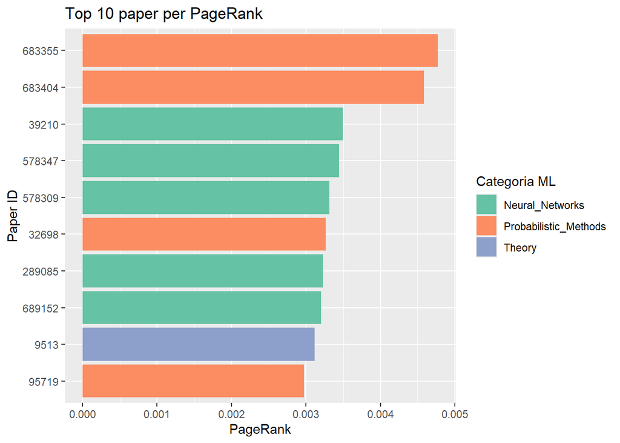

```r
ggplot(top_pagerank, aes(x = reorder(name, pagerank), y = pagerank, fill = category)) +
  geom_col() +
  coord_flip() +
  labs(
    title = "Top 10 paper per PageRank",
    x = "Paper ID",
    y = "PageRank",
    fill = "Categoria ML"
  ) +
  scale_fill_brewer(palette = "Set2")
```

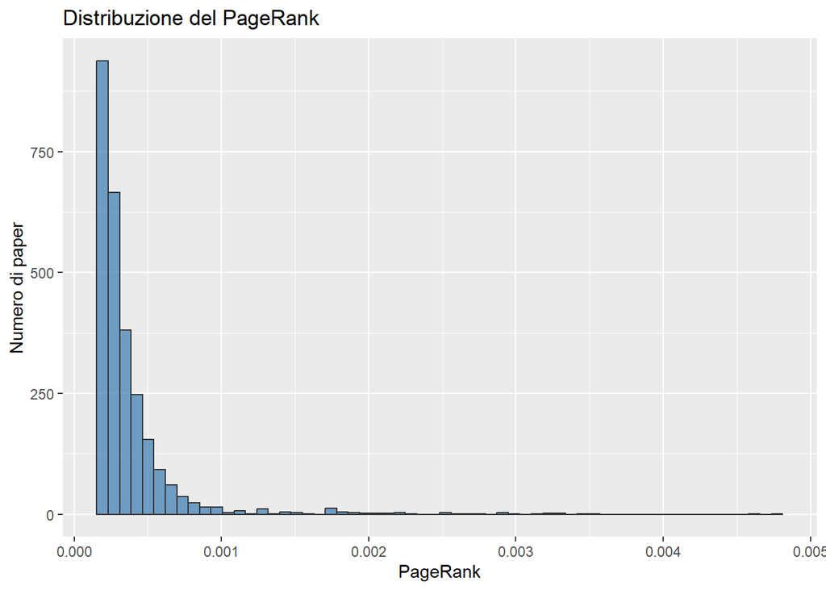

```r
# Distribuzione Globale del PageRank
graph %>%
  as_tibble() %>%
  ggplot(aes(pagerank)) +
  geom_histogram(bins = 60, fill = "steelblue", color = "gray20", alpha = 0.75) +
  labs(
    title = "Distribuzione del PageRank",
    x = "PageRank",
    y = "Numero di paper"
  )
```

## 2.6 : HITS

Qui si valuta l’importanza di un nodo anche in base a quanto sono importanti i noti citati dal nodo analizzato (Hub)

Qui abbiamo 2 tipi di nodi centrali :

- Autorità : contengono informazioni importanti riguardo il topic di interesse
- Hub : mi dice dov trovare le informazioni autorevoli

Un nodo può anche essr entrambi o nessuno

La Kleinberg centrality thesis dice :

Un nodo è un’ Autorità se è linkato da Hubs, è un Hub se linka delle Autorità.

```r
# Calcolo di HITS (Hub e Authority scores)
hits_result <- authority_score(graph, scale = TRUE)
hub_result <- hub_score(graph, scale = TRUE)

# Aggiungo entrambi ai nodi del grafo
graph <- graph %>%
  mutate(
    authority = hits_result$vector,
    hub = hub_result$vector
  )
```

Top 10 Authorities (paper autorevoli)

```r
top_authority <- graph %>%
  as_tibble() %>%
  arrange(desc(authority)) %>%
  select(name, authority, category) %>%
  head(10)

print(top_authority)
```

```
## # A tibble: 10 × 3
##    name    authority category
##    <chr>       <dbl> <chr>
##  1 1154459     1     Genetic_Algorithms
##  2 1152421     1     Genetic_Algorithms
##  3 1153280     1     Genetic_Algorithms
##  4 1153943     0.983 Genetic_Algorithms
##  5 1119708     0.960 Genetic_Algorithms
##  6 84021       0.958 Genetic_Algorithms
##  7 273152      0.949 Genetic_Algorithms
##  8 1127913     0.926 Genetic_Algorithms
##  9 98698       0.915 Genetic_Algorithms
## 10 568857      0.912 Genetic_Algorithms
```

Top 10 Hub (paper che linkano autorità)

```r
top_hub <- graph %>%
  as_tibble() %>%
  arrange(desc(hub)) %>%
  select(name, hub, category) %>%
  head(10)

print(top_hub)
```

```
## # A tibble: 10 × 3
##    name      hub category
##    <chr>   <dbl> <chr>
##  1 35     1      Genetic_Algorithms
##  2 82920  0.107  Genetic_Algorithms
##  3 85352  0.0818 Genetic_Algorithms
##  4 1688   0.0653 Genetic_Algorithms
##  5 287787 0.0614 Genetic_Algorithms
##  6 14062  0.0488 Genetic_Algorithms
##  7 210871 0.0469 Genetic_Algorithms
##  8 41714  0.0380 Genetic_Algorithms
##  9 12576  0.0348 Genetic_Algorithms
## 10 103515 0.0315 Genetic_Algorithms
```

Vediamo come sono distribuiti i vari paper

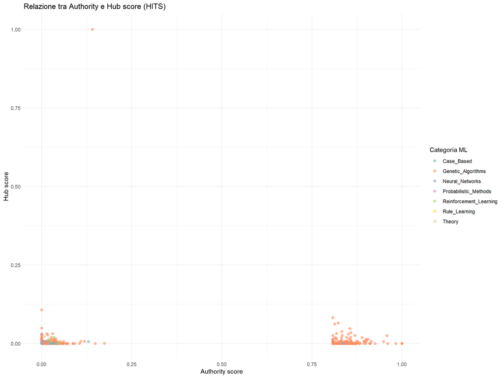

```r
graph %>%
  as_tibble() %>%
  ggplot(aes(x = authority, y = hub, color = category)) +
  geom_point(alpha = 0.6, size = 2) +
  scale_color_brewer(palette = "Set2") +
  labs(
    title = "Relazione tra Authority e Hub score (HITS)",
    x = "Authority score",
    y = "Hub score",
    color = "Categoria ML"
  ) +
  theme_minimal()
```

Da analisi precedenti sappiamo che ogni paper riceve al massimo 5 citazioni in totale.

Ciò si traduce nel fatto che un paper per essere un hub, ha solo 5 link a disposizione al massimo e deve cercare di linkare più authorities possibili.

Network dei top 100 paper per authority score.

Vediamo tale rete prima in base all’Authority Score, e poi mantenendo edges e nodi ne mostriamo anche il relativo Hub Score.

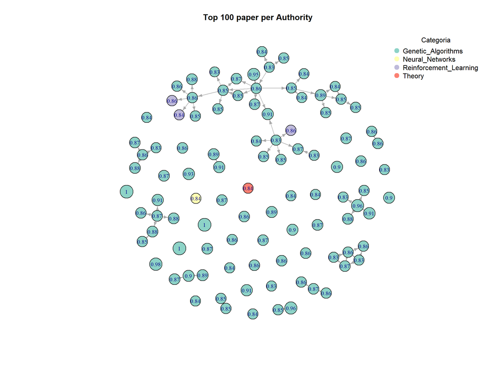

```r
# Estraggo i nomi dei top 100 paper per authority
top100_authority_ids <- graph %>%
  activate(nodes) %>%
  as_tibble() %>%
  arrange(desc(authority)) %>%
  head(100) %>%
  pull(name)

# Creo il subgrafo indotto da questi 100 nodi
igraph_sub <- induced_subgraph(graph, vids = which(V(graph)$name %in% top100_authority_ids))

coords <- layout_with_fr(igraph_sub)

palette_categoria <- RColorBrewer::brewer.pal(length(unique(V(igraph_sub)$category)), "Set3")
colori_nodi <- palette_categoria[as.numeric(as.factor(V(igraph_sub)$category))]


# Plot Authority
plot(
  igraph_sub,
  layout = coords,
  vertex.size = 8 + 12 * (V(igraph_sub)$authority - min(V(igraph_sub)$authority)) / max(V(igraph_sub)$authority),
  vertex.color = colori_nodi,
  vertex.label = round(V(igraph_sub)$authority, 2),
  vertex.label.cex = 0.8,
  edge.arrow.size = 0.5,
  main = "Top 100 paper per Authority"
)

# Legenda
legend(
  "topright",
  legend = levels(as.factor(V(igraph_sub)$category)),
  col = palette_categoria,
  pch = 19,
  pt.cex = 1.5,
  bty = "n",
  title = "Categoria"
)
```

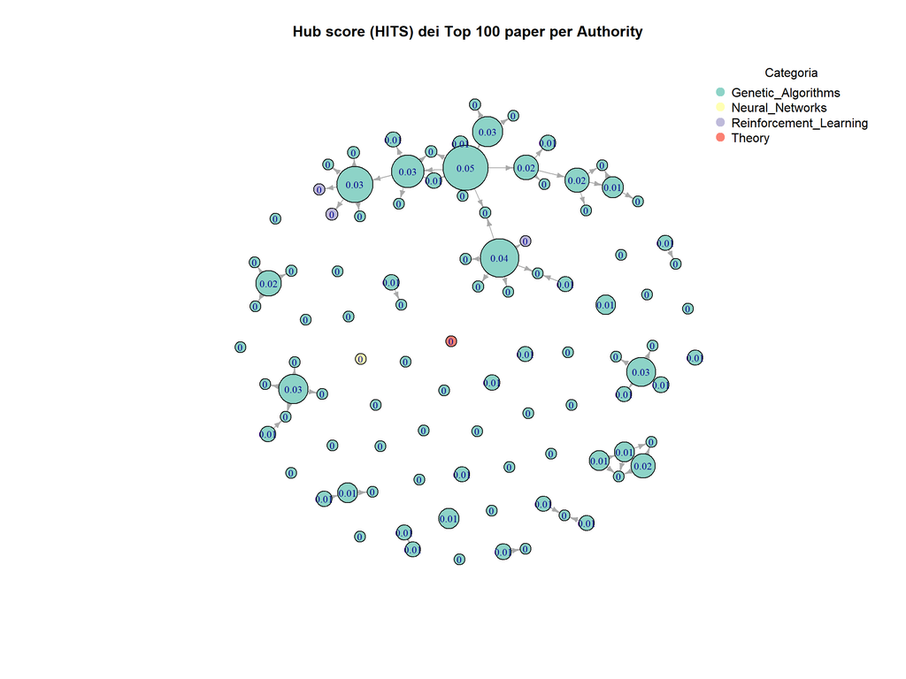

```r
# Plot Hub con
plot(
  igraph_sub,
  layout = coords,
  vertex.size = 5 + 15 * (V(igraph_sub)$hub - min(V(igraph_sub)$hub)) / max(V(igraph_sub)$hub),
  vertex.color = colori_nodi,
  vertex.label = round(V(igraph_sub)$hub, 2),
  vertex.label.cex = 0.8,
  edge.arrow.size = 0.5,
  main = "Hub score (HITS) dei Top 100 paper per Authority"
)

legend(
  "topright",
  legend = levels(as.factor(V(igraph_sub)$category)),
  col = palette_categoria,
  pch = 19,
  pt.cex = 1.5,
  bty = "n",
  title = "Categoria"
)
```

## 2.7 : Katz centrality

Questa metrica supera i problemi della Eigenvector Centrality nel nostro contsto.

L’idea è di dare ad ogni nodo uno small amount di centrality in modo gratuito.

Dunque :

Un nodo è importante se se è linkdato da nodi importanti o se riceve tanti archi entranti.

Quindi un paper ha alta Katz se riceve citazioni da paper che a loro volta ricevono molte citazioni.

Nel codice subito sotto :

- Calcolare il raggio spettrale r (massimo autovalore in valore assoluto)
- Usare alpha = 0.85/r (damping factor) per garantire convergenza (serve alpha < 1/r)
- Calcolare la Katz Centrality mediante la funzione alpha_centrality(), che implementa la formula di Katz

```r
A <- as_adjacency_matrix(graph, sparse = TRUE)
eig <- eigen(A)$values
r = max(abs(eig))
alpha <- 0.85 / r
katz <- alpha_centrality(graph, alpha = alpha)

# Aggiungo come attributo dei nodi la Katz calcolata
graph <- graph %>%
  mutate(katz = katz)

graph
```

```
## # A tbl_graph: 2708 nodes and 5429 edges
## #
## # A directed simple graph with 78 components
## #
## # Node Data: 2,708 × 10 (active)
##    name    category  indegree outdegree pagerank closeness betweenness authority
##    <chr>   <chr>        <dbl>     <dbl>    <dbl>     <dbl>       <dbl>     <dbl>
##  1 31336   Neural_N…        2         3 0.000217     0.333           0   1.50e-5
##  2 1061127 Rule_Lea…        1         0 0.000199   NaN               0   4.04e-4
##  3 1106406 Reinforc…        4         0 0.000305   NaN               0   1.99e-2
##  4 13195   Reinforc…        0         3 0.000192     0.333           0   0
##  5 37879   Probabil…        0         1 0.000192     1               0   0
##  6 1126012 Probabil…        2         0 0.000248   NaN               0   5.26e-3
##  7 1107140 Theory           2         0 0.000251   NaN               0   2.59e-4
##  8 1102850 Neural_N…        1         0 0.000207   NaN               0   3.86e-6
##  9 31349   Neural_N…        4         1 0.000340     1               0   1.56e-5
## 10 1106418 Theory           4         0 0.000554   NaN               0   1.89e-4
## # ℹ 2,698 more rows
## # ℹ 2 more variables: hub <dbl>, katz <dbl>
## #
## # Edge Data: 5,429 × 2
##    from    to
##   <int> <int>
## 1   164   403
## 2   164   660
## 3   164  1697
## # ℹ 5,426 more rows
```

Il problema della Katz Centrality è che:

Se un nodo con alta centralità è connesso a tanti altri nodi -> tutti questi altri nodi linkati acquisiscono alta Centralità.

La centralità guadagnata in virtù del ricevere un link da un nodo importante dovrebbe esser diluita se il nodo importante è molto proponso a linkare altri nodi.

Il PageRank risolve questo problema.

## 3 : Paragoni tra le centralità

```r
# Estraggo i nodi come dataframe
nodes <- graph %>% activate(nodes) %>% as_tibble()

# Computo la media per ciascuna metrica e categoria
compare <- nodes %>%
  group_by(category) %>%
  summarise(
    avg_indegree = mean(indegree, na.rm = TRUE),
    avg_outdegree = mean(outdegree, na.rm = TRUE),
    avg_pagerank = mean(pagerank, na.rm = TRUE),
    avg_closeness = mean(closeness, na.rm = TRUE),
    avg_betweenness = mean(betweenness, na.rm = TRUE),
    avg_katz = mean(katz, na.rm = TRUE),
    # Numero di paper in quella categoria
    n = n()
  ) %>%
  # Ordina per vedere una metrica in particolare
  arrange(desc(avg_pagerank))

compare
```

```
## # A tibble: 7 × 8
##   category avg_indegree avg_outdegree avg_pagerank avg_closeness avg_betweenness
##   <chr>           <dbl>         <dbl>        <dbl>         <dbl>           <dbl>
## 1 Probabi…         1.94          1.97     0.000410         0.386            83.9
## 2 Theory           2.16          2.34     0.000383         0.388            89.6
## 3 Genetic…         2.23          2.24     0.000373         0.436            58.9
## 4 Case_Ba…         1.97          1.75     0.000364         0.358            35.2
## 5 Neural_…         1.80          1.79     0.000362         0.424            52.3
## 6 Reinfor…         2.33          2.47     0.000331         0.417            94.9
## 7 Rule_Le…         1.94          1.74     0.000325         0.499            77.6
## # ℹ 2 more variables: avg_katz <dbl>, n <int>
```

Questo plot riassume e comunica quali categorie sono più centrali, intermediarie o ben collegate nella rete secondo le diverse misure.

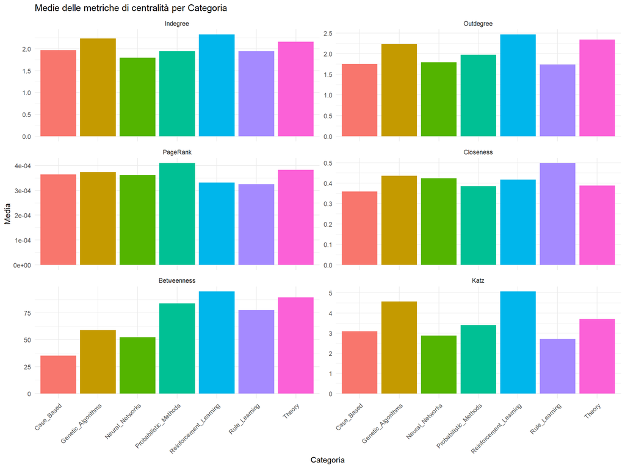

```r
# Ristruttura i dati in formato long per ggplot
compare_long <- compare %>%
  select(-n) %>%
  pivot_longer(-category, names_to = "metric", values_to = "mean_value") %>%
  mutate(metric = factor(metric,
                         levels = c("avg_indegree", "avg_outdegree", "avg_pagerank", "avg_closeness", "avg_betweenness", "avg_katz"),
                         labels = c("Indegree", "Outdegree", "PageRank", "Closeness", "Betweenness", "Katz")))


# Grafico a barre con faceting per metrica
ggplot(compare_long, aes(x = category, y = mean_value, fill = category)) +
  geom_col(show.legend = FALSE) +
  facet_wrap(~ metric, scales = "free_y", ncol = 2) +
  theme_minimal() +
  theme(axis.text.x = element_text(angle = 45, hjust = 1)) +
  labs(title = "Medie delle metriche di centralità per Categoria",
       x = "Categoria",
       y = "Media")
```

Vediamo ora la correlazione tra le varie misure di Centralità.

```r
M <- compare %>%
  select(avg_indegree, avg_outdegree, avg_pagerank, avg_closeness, avg_betweenness, avg_katz) %>%
  as.matrix()

# Calcolo la matrice delle correlazioni
corM <- cor(M, use = "complete.obs")

print(corM)
```

```
##                 avg_indegree avg_outdegree avg_pagerank avg_closeness
## avg_indegree      1.00000000    0.90668888  -0.16784298   -0.03438829
## avg_outdegree     0.90668888    1.00000000   0.05012675   -0.14692680
## avg_pagerank     -0.16784298    0.05012675   1.00000000   -0.63081338
## avg_closeness    -0.03438829   -0.14692680  -0.63081338    1.00000000
## avg_betweenness   0.48119334    0.64018461  -0.04721072    0.22317027
## avg_katz          0.92672368    0.90208370  -0.06260163   -0.10470455
##                 avg_betweenness    avg_katz
## avg_indegree         0.48119334  0.92672368
## avg_outdegree        0.64018461  0.90208370
## avg_pagerank        -0.04721072 -0.06260163
## avg_closeness        0.22317027 -0.10470455
## avg_betweenness      1.00000000  0.41906462
## avg_katz             0.41906462  1.00000000
```

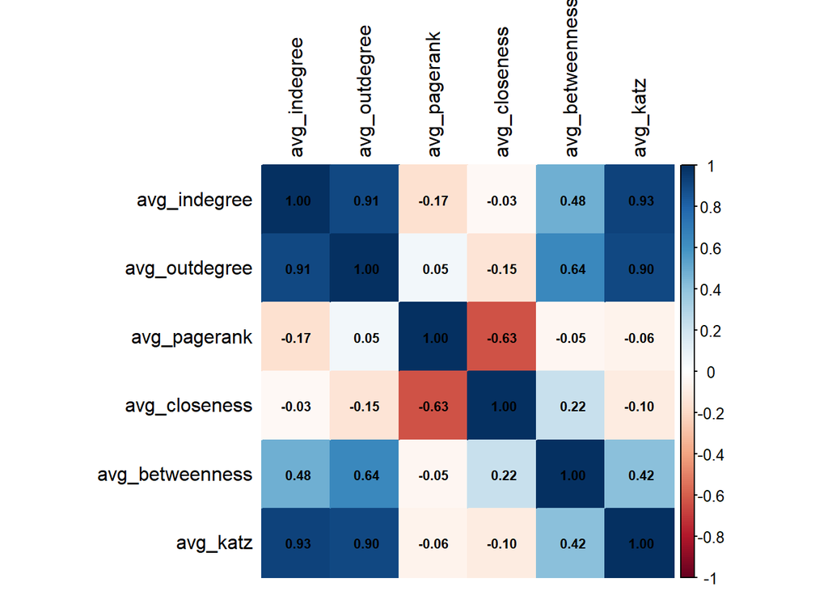

```r
corrplot(corM, method = "color", addCoef.col = "black", tl.col = "black", number.cex=0.7)
```

Le metriche di grado e Katz formano un cluster di misure fortemente correlate che riflettono l’attività immediata e l’influenza cumulativa nei network.

Pagerank e Closeness invece evidenziano aspetti più distinti della centralità, spesso inversamente correlati, rivelando diverse modalità di importanza nel network.

## 4 : Power

In alcune circostanze la Centralità ha un’utilità limitata nel predirre chi detiene il potere nelle reti.

Un nodo è MOLTO potente se è connesso con nodi POCO potenti.

La funzione sotto riportata implementa l’algoritmo iterativo di Bonacich Power Centrality.

La formula iterata è: x_(k+1) = (1 - x_k) · A

Il damping factor (0.15) serve per stabilità numerica.

Converge quando la differenza tra iterazioni consecutive è < 10^(-6)

Vediamo qui la funzion per calcolare la power.

Modifiche per evitare l’errore “Diff is NA”:

- Ad ogni iterazione verifica che (1 - x_2) %*% A non produca NA/NaN/Inf, altrimenti interrompe il ciclo con un errore esplicito.
- Normalizzazione: Divide x_2 per max(abs(x_2)) ad ogni passo per evitare overflow/underflow numerico che causerebbero valori NA.
- Aggiunto max_iter = 1000 per prevenire loop infiniti e conversione da matrice sparse a densa per evitare comportamenti inaspettati.

```r
power <- function(A, t) {
  n <- dim(A)[1]
  x_0 <- rep(0, n)
  x_1 <- rep(1, n)
  x_2 <- rep(1, n)
  diff <- 1
  eps <- 1 / 10^t
  iter <- 0
  max_iter <- 1000

  while (!is.na(diff) && diff > eps && iter < max_iter) {
    x_0 <- x_1
    x_1 <- x_2

    temp <- (1 - x_2) %*% A

    # Controllo valori invalidi
    if (any(is.na(temp)) || any(is.nan(temp)) || any(is.infinite(temp))) {
      stop("Valori non numerici (NA/NaN/Inf) rilevati durante l'iterazione power centrality")
    }

    x_2 <- as.vector(temp)

    # Normalizzazione vettore
    max_abs <- max(abs(x_2))
    if (max_abs > 0) {
      x_2 <- x_2 / max_abs
    }

    diff <- sum(abs(x_2 - x_0))
    iter <- iter + 1
  }

  if (is.na(diff)) stop("Diff is NA durante l'iterazione")
  return(list(vector = as.vector(x_2), iter = iter))
}
```

Calcolo effettivo della Power centrality

```r
# Conversione matrice sparsa in densa
A_dense <- as.matrix(A)

damping <- 0.15
n <- nrow(A_dense)
I <- diag(damping, n)
Ad <- A_dense + I

# Calcolo Power centrality
p <- power(Ad, 6)$vector

# Aggiunta al grafo
graph <- graph %>%
  mutate(power = p)

graph
```

```
## # A tbl_graph: 2708 nodes and 5429 edges
## #
## # A directed simple graph with 78 components
## #
## # Node Data: 2,708 × 11 (active)
##    name    category  indegree outdegree pagerank closeness betweenness authority
##    <chr>   <chr>        <dbl>     <dbl>    <dbl>     <dbl>       <dbl>     <dbl>
##  1 31336   Neural_N…        2         3 0.000217     0.333           0   1.50e-5
##  2 1061127 Rule_Lea…        1         0 0.000199   NaN               0   4.04e-4
##  3 1106406 Reinforc…        4         0 0.000305   NaN               0   1.99e-2
##  4 13195   Reinforc…        0         3 0.000192     0.333           0   0
##  5 37879   Probabil…        0         1 0.000192     1               0   0
##  6 1126012 Probabil…        2         0 0.000248   NaN               0   5.26e-3
##  7 1107140 Theory           2         0 0.000251   NaN               0   2.59e-4
##  8 1102850 Neural_N…        1         0 0.000207   NaN               0   3.86e-6
##  9 31349   Neural_N…        4         1 0.000340     1               0   1.56e-5
## 10 1106418 Theory           4         0 0.000554   NaN               0   1.89e-4
## # ℹ 2,698 more rows
## # ℹ 3 more variables: hub <dbl>, katz <dbl>, power <dbl>
## #
## # Edge Data: 5,429 × 2
##    from    to
##   <int> <int>
## 1   164   403
## 2   164   660
## 3   164  1697
## # ℹ 5,426 more rows
```

## 5 : Paragone tra Power and Katz Centrality

Alta Katz = Paper molto citato da altri paper autorevoli (è un “riferimento” nella comunità)

Alta Power = Paper che può influenzare altri paper

```r
cat("Top-5 states by katz centrality : \n\n")
```

```
## Top-5 states by katz centrality :
```

```r
# sort top-5 states according to katz centrality

round(sort(katz, decreasing=TRUE)[1:5], 3)
```

```
## 126927 127033 416455 645897  63832
## 27.225 23.378 23.116 22.062 21.520
```

```r
cat("Top-5 states by Power : \n\n")
```

```
## Top-5 states by Power :
```

```r
# sort top-5 states according to power

round(sort(p, decreasing=TRUE)[1:5], 2)
```

```
## [1] 1.00 1.00 0.94 0.93 0.92
```

```r
# correlation
cat("Correlazione di Kendall tra Katz e Power : ")
```

```
## Correlazione di Kendall tra Katz e Power :
```

```r
cor(katz, p, method="kendall")
```

```
## [1] 0.5634994
```

La correlazione di Kendall tra Katz e Power è circa 0.56, indicando una correlazione moderata: i due indici sono legati ma misurano aspetti leggermente diversi della centralità.

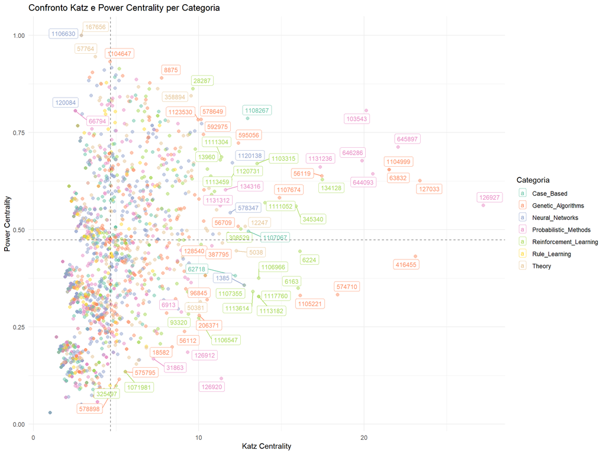

```r
nodes <- graph %>% activate(nodes) %>% as_tibble()

# Calcola i quantili 75% per Katz e Power:

q_katz <- quantile(nodes$katz, 0.75)
q_power <- quantile(nodes$power, 0.75)

# Visualizza con ggplot2 la relazione tra Katz e Power, aggiungendo linee ai quantili e le etichette:

top_nodes <- nodes %>% filter(katz > q_katz | power > q_power)

ggplot(nodes, aes(x = katz, y = power, color = category)) +
  geom_point(alpha = 0.5, size = 2) +
  geom_label_repel(data = top_nodes, aes(label = name),
                   max.overlaps = 15, size = 3) +
  geom_hline(yintercept = q_power, linetype = "dashed", alpha = 0.5) +
  geom_vline(xintercept = q_katz, linetype = "dashed", alpha = 0.5) +
  scale_color_brewer(palette = "Set2") +
  labs(title = "Confronto Katz e Power Centrality per Categoria",
       x = "Katz Centrality", y = "Power Centrality",
       color = "Categoria") +
  theme_minimal()
```

## 6 : Uso delle 2 matrici proiezioni A %*% t(A) e t(A) %*% A (prodotto matriciale)

- Trova le 30 coppie (i, j) con più paper citati in comune (common successors)
- Trova le 30 coppie con più paper citanti in comune (common predecessors)

Voglio studiare ora quanti paper citanti hanno in comune 2 paper i e j, e quanti paper citanti hanno in comune 2 paper i e j

```r
# Richiesta la libreria MAtrix

# Matrice di adiacenza (sparse, più efficiente)
A <- as_adj(graph, sparse = TRUE)

# Matrice dei paper citati in comune (successori comuni)
common_cited <- as.matrix(A %*% t(A))
diag(common_cited) <- 0  # opzionale, azzeri la diagonale

# Matrice dei paper citanti in comune (predecessori comuni)
common_citing <- as.matrix(t(A) %*% A)
diag(common_citing) <- 0



# Trova le 30 coppie (i, j) con più paper citati in comune
top_cited <- which(common_cited == max(common_cited), arr.ind = TRUE)
top_cited_df <- as.data.frame(top_cited)
top_cited_df$shared_cited = common_cited[top_cited]

# Trova le 30 coppie con più paper citanti in comune
top_citing <- which(common_citing == max(common_citing), arr.ind = TRUE)
top_citing_df <- as.data.frame(top_citing)
top_citing_df$shared_citing = common_citing[top_citing]



get_top_pairs <- function(mat, topn = 30) {
  ind <- which(upper.tri(mat), arr.ind = TRUE)
  vals <- mat[ind]
  ord <- order(vals, decreasing = TRUE)[1:topn]
  data.frame(
    paper_i = ind[ord, "row"],
    paper_j = ind[ord, "col"],
    shared = vals[ord]
  )
}
top30_cited = get_top_pairs(common_cited, 30)
top30_citing = get_top_pairs(common_citing, 30)

# (Facoltativo: aggiungi titolo/autore ai risultati usando le label dei nodi)
# V(graph)$label oppure il campo desiderato

head(top30_cited)
```

```
##   paper_i paper_j shared
## 1     553     566     20
## 2     164     794     15
## 3     295     566     13
## 4     571     577     12
## 5     746     748     12
## 6     164    1154     12
```

```r
head(top30_citing)
```

```
##   paper_i paper_j shared
## 1    1482    1674      5
## 2    2414    2415      5
## 3       9     436      4
## 4      86     467      4
## 5     174     467      4
## 6       9     545      4
```

Network delle Top 30 Coppie con Più Paper Citati in Comune.

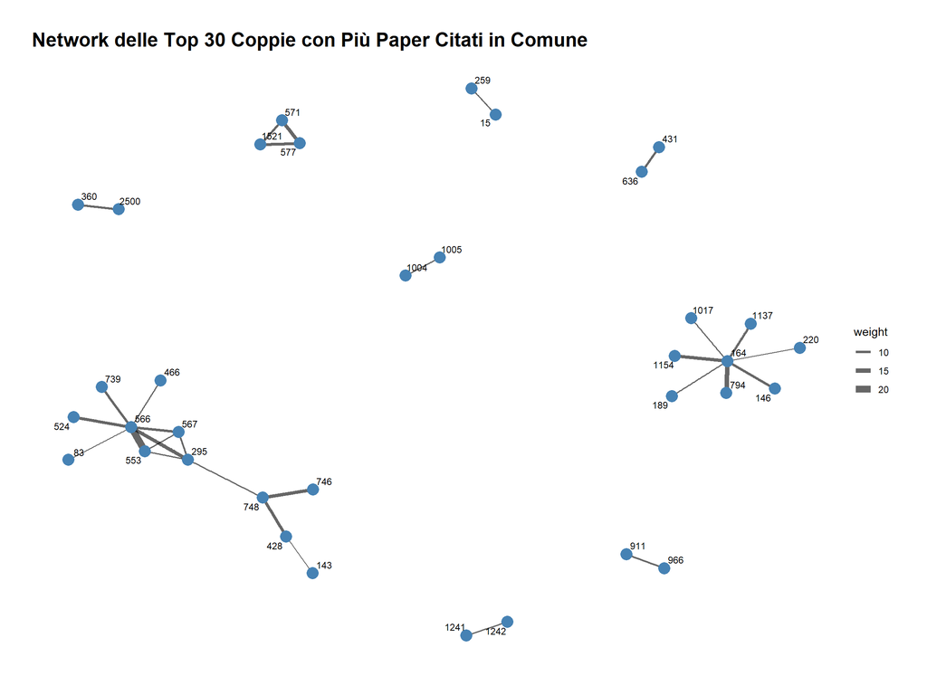

```r
# Crea edge list dalle top 30 coppie
edges_cited <- top30_cited %>%
  select(from = paper_i, to = paper_j, weight = shared)

# Crea grafo
g_cited <- graph_from_data_frame(edges_cited, directed = FALSE)

ggraph(g_cited, layout = "fr") +
  geom_edge_link(aes(width = weight), alpha = 0.6) +
  geom_node_point(size = 5, color = "steelblue") +
  geom_node_text(aes(label = name), repel = TRUE, size = 3) +
  scale_edge_width(range = c(0.5, 3)) +
  labs(title = "Network delle Top 30 Coppie con Più Paper Citati in Comune") +
  theme_graph()
```

## Salvataggio Metriche computate

```r
## Salvataggio Metriche computate

dir_processed <- "../data/processed"

if (!dir.exists(dir_processed)) {
  dir.create(dir_processed, recursive = TRUE)
}

# Salva il grafo completo con tutte le metriche di centralità
save(graph, file = file.path(dir_processed, "graph_with_centralities.RData"))

# Verifica attributi nodi salvati
cat("\n=== ATTRIBUTI NODI SALVATI ===\n")
```

```
##
## === ATTRIBUTI NODI SALVATI ===
```

```r
cat(paste(vertex_attr_names(graph), collapse = ", "), "\n")
```

```
## name, category, indegree, outdegree, pagerank, closeness, betweenness, authority, hub, katz, power
```

```r
# Salva anche una versione CSV dei nodi per analisi esterne
nodes_data <- graph %>%
  activate(nodes) %>%
  as_tibble()

write.csv(nodes_data,
          file.path(dir_processed, "nodes_with_centralities.csv"),
          row.names = FALSE)

# Salva anche gli archi con attributi (se ne hai aggiunti)
edges_data <- graph %>%
  activate(edges) %>%
  as_tibble()

write.csv(edges_data,
          file.path(dir_processed, "edges_data.csv"),
          row.names = FALSE)

# Stampa riepilogo
cat("\n=== SALVATAGGIO COMPLETATO ===\n")
```

```
##
## === SALVATAGGIO COMPLETATO ===
```

```r
cat("✓ Grafo salvato in:", file.path(dir_processed, "graph_with_centralities.RData"), "\n")
```

```
## ✓ Grafo salvato in: ../data/processed/graph_with_centralities.RData
```

```r
cat("✓ Tabella nodi salvata in:", file.path(dir_processed, "nodes_with_centralities.csv"), "\n")
```

```
## ✓ Tabella nodi salvata in: ../data/processed/nodes_with_centralities.csv
```

```r
cat("✓ Tabella archi salvata in:", file.path(dir_processed, "edges_data.csv"), "\n")
```

```
## ✓ Tabella archi salvata in: ../data/processed/edges_data.csv
```

```r
cat("\n=== INFORMAZIONI GRAFO ===\n")
```

```
##
## === INFORMAZIONI GRAFO ===
```

```r
cat("  • Numero di nodi:", vcount(graph), "\n")
```

```
##   • Numero di nodi: 2708
```

```r
cat("  • Numero di archi:", ecount(graph), "\n")
```

```
##   • Numero di archi: 5429
```

```r
cat("  • Numero di metriche calcolate:", length(vertex_attr_names(graph)) - 1, "\n")
```

```
##   • Numero di metriche calcolate: 10
```